# Analise RNASeq a celulas humanas TNBC

Grupo 2: Francisco Costa PG32922 | Mário Varela PG37984 | Rui Pires PG38280 | Patrícia MAchado PG30377

# 1 Introdução - RNASeq

Neste trabalho serão analizados os dados transcriptómicos resultantes do *Triple Negative Breast Cancer Stem Cells* e *Differentiated Tumor Cells* com o objectivo de encontrar diferenças entre os genes expressos nos cromossomas de modo a identificar um possível *drug target* . Foram usadas 2 linhas celurares pertencentes a *Mus musculus* e *Homo sapiens*.

A análise de *count data* resultante do RNA-seq é uma tarefa básica que permite detetar gene expressos diferencialmente. A *count data* é apresentada numa tabela que reporta para cada amostra, o número de fragmentos numa sequência que foram assimilados a cada gene. A partir da análise destes dados é importante quantificar e fazer inferências estatísticas de mudanças sistemáticas entre condições, quando comparado com a variabilidade dentro da condição. A package DESeq2 tem métodos capazes de testar expressão diferencial ao usar glms(generalized linear models) binomiais negativos e ainda estimar a dispersão, *fold-change* e as suas respetivas distribuições. *Para realizar com sucesso esta análise é necessário primeiro: +implementar pipeline que a partir dos ficheiros FASTQ permita gerar fastqc reports e análise, ponto 2.1; realizar o Trimmomatic, com intuito de melhorar a qualidade dos dados e por fim realizar o alinhamento e obter a* Burrows-Wheeler Matrix* através do método *Burrows-Wheeler Aligner*(bwa) +implementar um RNASeq workflow capaz de gerar dados que permitar fazer inferências estatísticas sobre os dados estudados.

# 2 Pré Processamento dos dados - Linux

## 2.1 Gerar fastQC reports

Download dados

```bash
$ /NGSDatasets/reads/breast/IlluminaHiSeq2000/homosapiens/download_dataset.sh
# SRR6638905.fastq.gz  SRR6638906.fastq.gz  SRR6638907.fastq.gz  SRR6638908.fastq.gz
```

Os reads SRR6638909 e SRR6638910, adicionados posteriormente ao dataset, foram obtidos através do comando ln -s* . Gerar relatórios fastQC (fastqc $fq) das reads: Estes relatórios vão servir como controlo de qualidade dos dados, para assegurar que a *raw data* parece correcta e não há problemas ou *bias*.

```bash
#Contruir ficheiro sh, bulkfastqc.sh, com script para para gerar relatórios, com o seguinte conteúdo:

#!/bin/bash
for fq in `ls *.fastq.gz`
do
    echo $fq
    fastqc $fq
done

#executar script:
$ chmod +x bulkfastqc.sh
$ ./bulkfastqc.sh
```

Para cada ficheiro, são gerados um fastqc.zip e o respectivo relatório no formato html onde os resultados são apresentados e analisados. Deste processo resulta: + 1 Plot “box-and-whisker” permite visualizar os resultados estatísticos agregados em cada posição de todos os reads do ficheiro; + Plot do nº total de reads vs a qualidade do score sobre o total do read é também otido como qualidade de scores da sequência; + Contagem de GC (em percentagem e vs nº de reads) - formação de uma distribuição normal com pico da média de GC presente no organismo sequenciado (células mamárias; no caso das sequncias de RNA existe uma distribuição maior ou menor ao longo dos transcripts o que provoca a visualização de um plot mais amplo ou mais estreiro do que é o ideal para uma distribuição normal ); + É possível ainda obter a duplicação dos níveis da sequncia (percentagem de reads da sequencia que estão presentes mais vezes no ficheiro); + Conteúdo de adaptadores (plot cumulativo da fracção de reads onde apenas adaptadores específicos da sequencia (tipo de biblioteca correspondente) é procurada. + É analisado o conteúdo Kmer onde é medida a contagem de cada pequeno nucleotido de comprimento k.

Os nossos resultados cumprem na maioria com o threshold estabelecido para cada passo da avaliação, excepto no *Per base sequence content*, onde pode ser observada uma diferença entre percentagem de ocorrencia de nucleotidos, nas posições iniciais das leituras, isto pode ser devido à presença de dimeros de adaptadores ou presença de rRNA que acrescenta um número de diferentes k-mers na extremidade 5’ das leituras. Apesar do *warning/error* no report podemos afirmar que a qualidade dos reads está assegurada após a sua correção com trimming com recurso ao Trimmomatic.

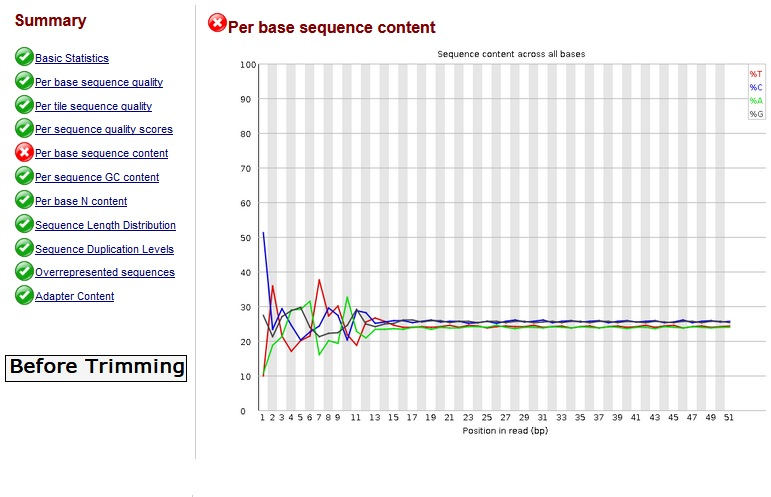

## 2.2 Trimmomatic

Trimmomatic (especificamente, trimmomatic-0.39-1) foi usado com objectivo de melhorar a qualidade das nossas leituras e remoção a zona das posições iniciais da sequência.

```bash
#Contruir ficheiro sh, bulktrimm.sh , com script para aplicar trimmomatic a todos os ficheiros, com o seguinte conteúdo:

#!/bin/bash

for fq in `ls *.fastq.gz`
do
    echo $fq
    java -jar /opt/conda/pkgs/trimmomatic-0.39-1/share/trimmomatic-0.39-1/trimmomatic.jar SE $fq TRIMMED_"$fq" ILLUMINACLIP:/NGSDatasets/adapters/IlluminaHiSeq2000/TruSeq3-SE.fa:2:30:10 HEADCROP:12
done

#executado script:
$ chmod +x bulktrimm.sh
$ ./bulktrimm.sh

#criação de novos ficheiros fastq com prefixo 'TRIMMED_'
```

Novos relatorios fastqc foram gerados para avaliar a qualidade dos reads pós *trim*. Todas as sequências têm uma avaliação positiva no “Per base sequence content” mas geram avisos no “Sequence Length Distribution”, uma explicação para estes avisos é o clip não uniforme dos adaptares nos varios reads, comum em varias bibliotecas de sequencias, como tal a qualidade dos reads está garantida e podem ser utilizados para alinhamentos. Os varios relatorios fastqc para todos os reads estao presentes na pasta */home/group2/fastqcReport/*.

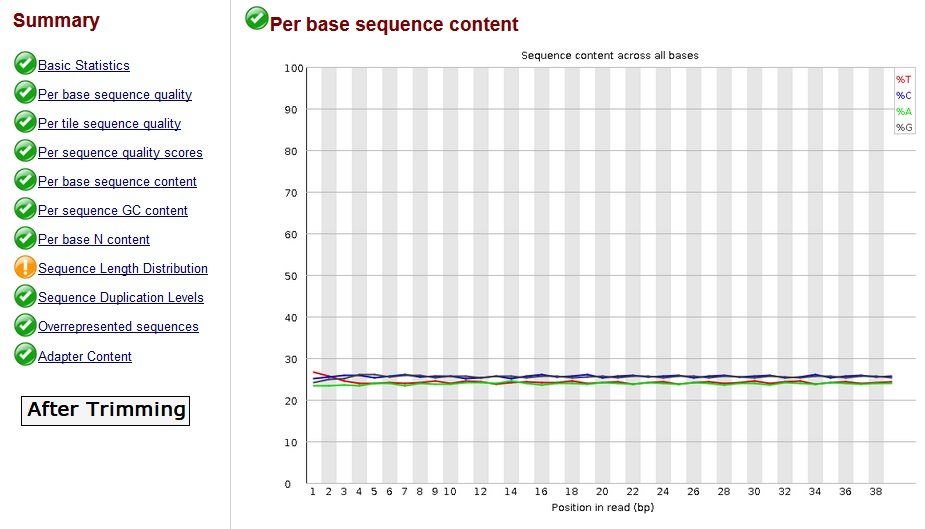

## 2.3 Alinhamento(BWA)

Nesta etapa foram criados 2 links simbólicos para os cromossomas 17 e 13 que foram indexados (bwa index). A escolha destes cromossamas reflete a relevancia dos genes neles presentes e na sua relação com o cancro mamário triplo negativo, nomeadamente BRCA1, BRIP1, RAD51, TP53 no cromossoma 17 e BRCA2 no cromossoma 13. Após o alinhamento de Burrows-Wheeler os reads foram alinhados ao cromossoma com geração de ficheiros .sai. O ficheiro bulkbam.sh foi criado para avaliar os dados de alinhamento gerando ficheiros bam através dos ficheiros .sai.

```bash
#Comandos para cromossoma 17, mesmos métodos foram aplicado so cromossoma 13
#criar link simbolico do cromossoma
$ ln -s /NGSDatasets/indexes/HomoSapiens/bycromossome/Homo_sapiens.GRCh38.dna.chromosome.17.fa.gz chr17.fa.gz

#indexar cromossoma, dá origem a ficheiros de vários formatos, amb, ann, bwt, etc.
$ bwa index chr17.fa.gz

#alinhar cromossoma indexado a ficheiros TRIMMED, script no ficheiro alignto17.sh com o seguinte conteúdo:

#!/bin/bash
for fq in `ls TRIMMED*.fastq.gz`
do
    echo $fq
    bwa aln chr17.fa.gz $fq > "$fq".sai
done

#executar script:
$ chmod +x alignto17.sh
$ bash alignto17.sh

#com  os ficheiros .sai do alinhamento entre os cromossomas e dados TRIMMED, podemos criar ficheiros bam para ver avaliar os dados do alinhamento
#É usada a opção samse, pois é a mais indicada para trabalhar com single-ends
#bulkbam para cromossoma 17
for num in {5..8}
do
    fq="SRR663890$num"
    echo ===============
    echo $fq
    echo ===============
    bwa samse chr17.fa.gz "TRIMMED_$fq".fastq.gz.sai "TRIMMED_$fq".fastq.gz | samtools view -S - -b > "$fq".bam
done
```

Daqui resultam os ficheiros no formato .bam, guardados nas pastas /home/group2/cromossoma17 e /home/group2/cromossoma13 respetivos, utilizados no próximo passo.

## 2.4 Contagem de read por gene mapeado

### 2.4.1 Contagens RPKM

```bash
#Usar a função htseq-count que requerem um ficheiro com anotação no formato GFF/GTF para usar com sequência de referência no fomato fasta

#obter o ficheiro gtf:
$ wget -N ftp://ftp.ensembl.org/pub/release-96/gtf/homo_sapiens/Homo_sapiens.GRCh38.96.gtf.gz

#contrui script sh, countreads17.sh, para mapear todos ficheiros .bam -> .readcounts. ex com o seguinte conteúdo:
#!/bin/bash
for fq in `ls *.bam`
do
    echo ======
    echo $fq
    echo ======
    htseq-count -f bam -s no -i gene_id $fq Homo_sapiens.GRCh38.96.gtf.gz > "$fq".readcounts
done


#com todos os valores de RPKM calculados para todos os genes fazemos uma tabela com todos os genes e valores para todos os reads:
$ echo "geneid SR05 SR06 SR07 SR08 SR09 SR10" > ch17finalreadcount.tab
$ paste *.readcounts | cut -f1,2,4,6,8,10,12 >> ch17finalreadcount.tab
```

Desta contagens vão resultar as tabelas ch17finalreadcount.tab e ch13finalreadcount.tab que vão ser usadas na análise de expressão diferencial.

# 3 Análise Expressão Diferencial

Para os seguintes propósito forem necessárias as respetivas packages: - Expressão diferencial: edgeR, limma, DESeq2; - Teste do gene set: limma; - Normalização: DESeq2; - Plot: gplots, pheatmap, RColorBrewe.

```r
#load de packages necessarios
dependencias <- c(
  'edgeR',
  'limma',
  'Glimma',
  'gplots',
  'DESeq2',
  'pheatmap',
  'RColorBrewer'
)

invisible(
  suppressWarnings(
    suppressMessages(
      lapply(dependencias,library,
             character.only = T,
             warn.conflicts = FALSE,
             quietly = TRUE)
      )
    )
  )
```

## 3.1 Análise RNASeq a celulas humanas TNBC alinhadas ao cromossoma 17

### 3.1.1 Carregar dados e respetivo pré-processamento:

```r
#Load de tabela de contagens
sr17 <- read.table("ch17finalreadcount.tab", h = T, row.names = 1)
tail(sr17) # fragmentos do ficheiro que não são necessários para a análise
```

```
##                           SR05    SR06    SR07    SR08    SR09    SR10
## ENSG00000286272              0       0       0       0       0       0
## __no_feature              8463    8782    8748    6234    7312    4362
## __ambiguous               6930    8642    9188    5628    6147    4085
## __too_low_aQual          12021   15125   15213   14224   16597   10699
## __not_aligned          3337046 4080785 4168837 3655715 4301655 2401236
## __alignment_not_unique       0       0       0       0       0       0
```

```r
#remover fragmentos
sr17 <- sr17[1:(nrow(sr17) - 5), ]
head(sr17)
```

```
##                 SR05 SR06 SR07 SR08 SR09 SR10
## ENSG00000000003    0    0    0    0    0    0
## ENSG00000000005    0    0    0    0    0    0
## ENSG00000000419    0    0    0    0    0    0
## ENSG00000000457    0    0    0    0    0    0
## ENSG00000000460    0    0    0    0    0    0
## ENSG00000000938    0    0    0    0    0    0
```

```r
#filtrar genes que não são expressos
sr17 <- sr17[rowSums(sr17) > 1,]
head(sr17)
```

```
##                 SR05 SR06 SR07 SR08 SR09 SR10
## ENSG00000002834   32   36   48   54   55   29
## ENSG00000002919    2    2    5    5    3    4
## ENSG00000004142   42   51   48   25   24   23
## ENSG00000004660    3    5    2    4    2    2
## ENSG00000004897   76   74   99   78   94   53
## ENSG00000004939    0    1    0    1    0    0
```

```r
dim(sr17) #dimensões após aplicar filtro
```

```
## [1] 945   6
```

```r
condition <- factor(c("bulk", "bulk", "bulk", "spheroid", "spheroid", "spheroid"))
cd <- data.frame(c("bulk", "bulk", "bulk", "spheroid", "spheroid", "spheroid"))
colnames(cd)[1] = "condition"
rownames(cd) = colnames(sr17)
```

### 3.1.2 Teste de expressão diferencial

```r
dds <- DESeqDataSetFromMatrix(countData = sr17,
                              colData = cd,
                              design = ~ condition)
dds <- DESeq(dds)
res <- results(dds)
res
```

```
## log2 fold change (MLE): condition spheroid vs bulk
## Wald test p-value: condition spheroid vs bulk
## DataFrame with 945 rows and 6 columns
##                          baseMean      log2FoldChange             lfcSE
##                         <numeric>           <numeric>         <numeric>
## ENSG00000002834  41.1357625778377   0.480315414039392  0.29466579647129
## ENSG00000002919  3.54744537184608   0.715441105219245 0.950107460755683
## ENSG00000004142  34.2537317783186  -0.705635748841715 0.326207100463171
## ENSG00000004660  2.93779336040796 -0.0706535595416628  1.02762806612185
## ENSG00000004897  76.5578905809169  0.0835442782841848 0.228228274158091
## ...                           ...                 ...               ...
## ENSG00000280136  1.96911418331695    1.85629141018949  1.39559510316418
## ENSG00000280351 0.315275334137098   -1.64994718983386  3.01482131583146
## ENSG00000280852   13.841542070262  -0.259372214087599 0.481922643646631
## ENSG00000283566  4.77018545027631   -0.11958565905892 0.834430579863646
## ENSG00000284242   152.98593585251   0.427737917750375  0.17521353919591
##                                stat             pvalue               padj
##                           <numeric>          <numeric>          <numeric>
## ENSG00000002834    1.63003449939325  0.103094205750098  0.275256450820459
## ENSG00000002919    0.75301072222947   0.45144347085975                 NA
## ENSG00000004142   -2.16315263475199 0.0305294419043192   0.11652786980381
## ENSG00000004660 -0.0687540189597015  0.945185418982915                 NA
## ENSG00000004897   0.366055777236062  0.714323455344893  0.881205905675277
## ...                             ...                ...                ...
## ENSG00000280136    1.33010742584349  0.183482879223275                 NA
## ENSG00000280351   -0.54727860028375  0.584187343503122                 NA
## ENSG00000280852  -0.538203003131314  0.590436906978355  0.810169122993084
## ENSG00000283566  -0.143314089805364  0.886042128642028                 NA
## ENSG00000284242    2.44123781594362 0.0146370123197446 0.0619785990414185
```

O data frame resultante contém informação importante para estudo dos dados como a coluna log2FoldChange e os padj(valores de p ajustados), que nos dizem o quanto a expressão do gene varia entre os tratamentos.

```r
mcols(res, use.names = TRUE) #metadados para legenda
```

```
## DataFrame with 6 rows and 2 columns
##                        type
##                 <character>
## baseMean       intermediate
## log2FoldChange      results
## lfcSE               results
## stat                results
## pvalue              results
## padj                results
##                                                       description
##                                                       <character>
## baseMean                mean of normalized counts for all samples
## log2FoldChange log2 fold change (MLE): condition spheroid vs bulk
## lfcSE                  standard error: condition spheroid vs bulk
## stat                   Wald statistic: condition spheroid vs bulk
## pvalue              Wald test p-value: condition spheroid vs bulk
## padj                                         BH adjusted p-values
```

```r
resOrdered <- res[order(res$padj),]
summary(res)
```

```
##
## out of 945 with nonzero total read count
## adjusted p-value < 0.1
## LFC > 0 (up)       : 58, 6.1%
## LFC < 0 (down)     : 80, 8.5%
## outliers [1]       : 0, 0%
## low counts [2]     : 403, 43%
## (mean count < 7)
## [1] see 'cooksCutoff' argument of ?results
## [2] see 'independentFiltering' argument of ?results
```

```r
sum(res$padj < 0.1, na.rm = TRUE)
```

```
## [1] 138
```

Ao ordernar os genes, de acordo com o valor de padj, pode-se observar que os genes com maior relevância são ENSG00000215030, ENSG00000108602, ENSG00000239291, ENSG00000230897, ENSG00000213228, ENSG00000228007. Ao considerar uma fração de falsos positivos de 10%, podemos considerar os genes com valor ajustado de p inferior a 0.1 como significativos(Verificamos que existem 138 genes que cumprem esta condição).

### 3.1.3 Exploração dos resultados

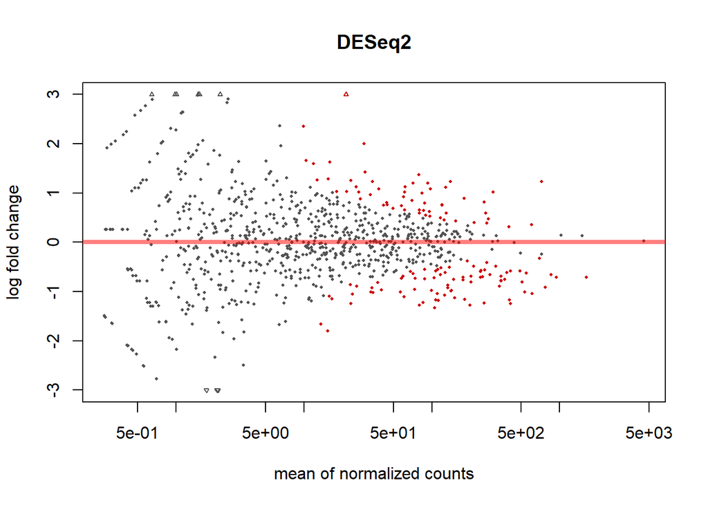

```r
#plot MA

DESeq2::plotMA(res, main = "DESeq2", ylim = c(-3, 3))
```

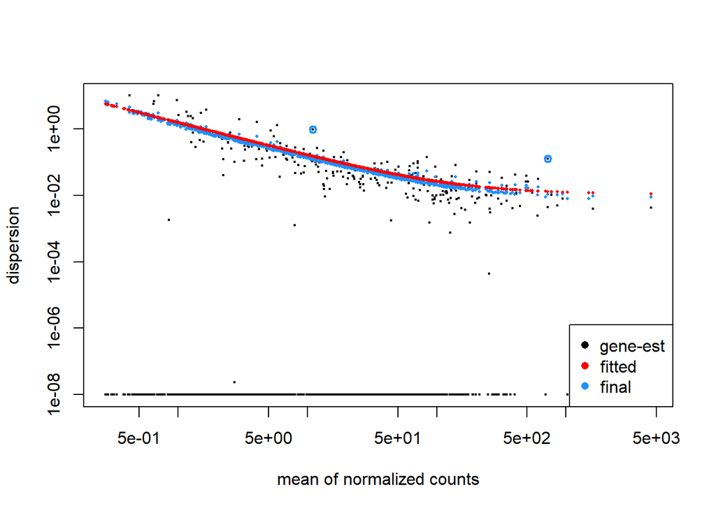

```r
#plotMA(res, ylim = c(-3, 3), col = ifelse(res$padj>=0.1, "gray32", "red3"), linecol = "#ff000080", xlab = "mean of normalized counts", ylab = expression(log[2]~fold~change), log = "x", cex=0.01)


#Dispersion plot
plotDispEsts(dds)
```

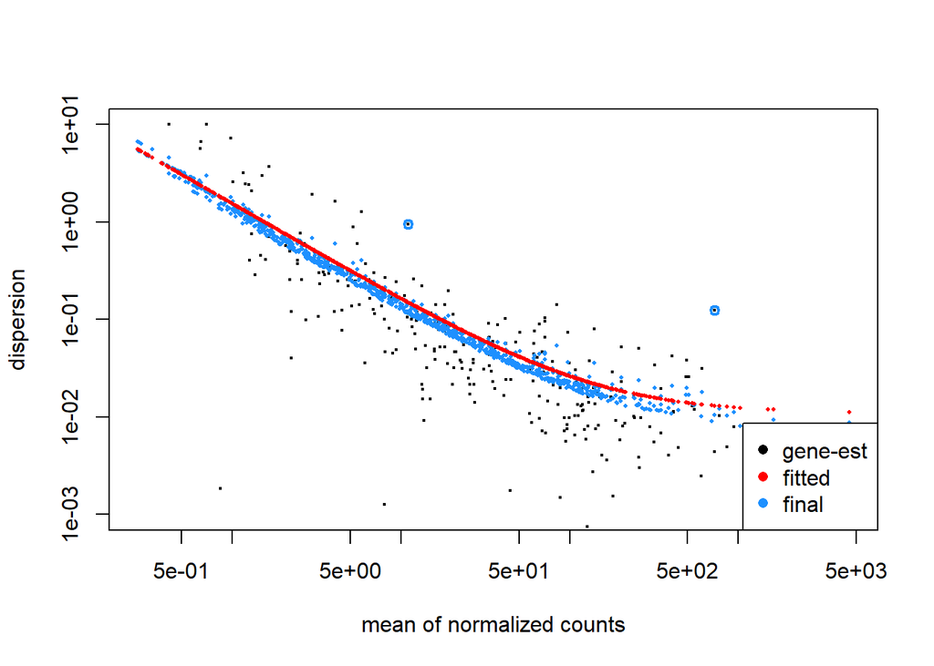

```r
plotDispEsts(dds, ylim = c(1e-3, 1e1))
```